# Macalester President’s House Electricity Usage: Trends, Analysis, and Conclusions

Author

Sam Anthony & Nick Kent

Published

October 8, 2025

Abstract

This report analyzes electricity usage from 2013 to present from the Old Macalester Presidents House. We use techniques from statistics to model the overall trend of the data, the seasonality or cyclic behavior within a year, and finally to model the errors or noise of the data. We use a linear model for trend, month as predictors for cyclic behavior, and a AR(2) model for the errors. We find a decreasing linear trend over time and cyclic patterns with highest electricity usage in the winter months. Finally, we forecast the next 24 months of electricity usage at the Old Presidents House.

## Introduction

Electricity and energy usage is a vital part of our lives because it powers everything from our homes, to electronic devices, businesses, many other things. It is important to note that electricity use has implications: greenhouse gas emissions and the cost of using electricity are just two reasons as to why we should keep a close eye on our energy usage/efficiency (Quevedo et al. (2024)). One place where electricity usage is very high is college campuses. More than 76% of all electricity usage and 40% of all primary energy use in the United States comes from buildings (Favela (2023)). In the United States there are roughly 4,000 colleges each of which have tons of buildings that require constant energy consumption for heating, cooling, lighting, etc (Favela (2023)). This means that making universities more energy efficient could have huge positive implications in terms of the total energy usage in the United States. As Macalester students with access to data on Macalester’s energy usage, we investigate the Presidents House’s electricity usage to determine whether the President as the leader of the college is making strides towards the college’s sustainability goals. Learning about trend and seasonality of usage can also help us target areas for improvement in usages of electricity which has so much impact.

## Data

The data used in this project is exclusively from the Macalester President’s House, where we are investigating the average energy usage per day over a one month period. For example, one observation in our data set might have a start date of 01/01/2014, an end date of 01/31/2014, and an average daily usage of 4291. This means that in January of 2014, the average energy usage per day was 4291. Below are exploratory plots of seasonality and average use per day over time to give some additional context of the data.

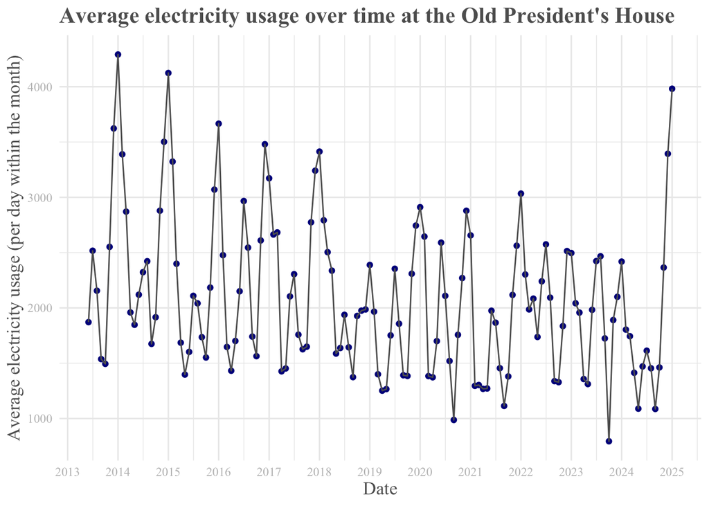

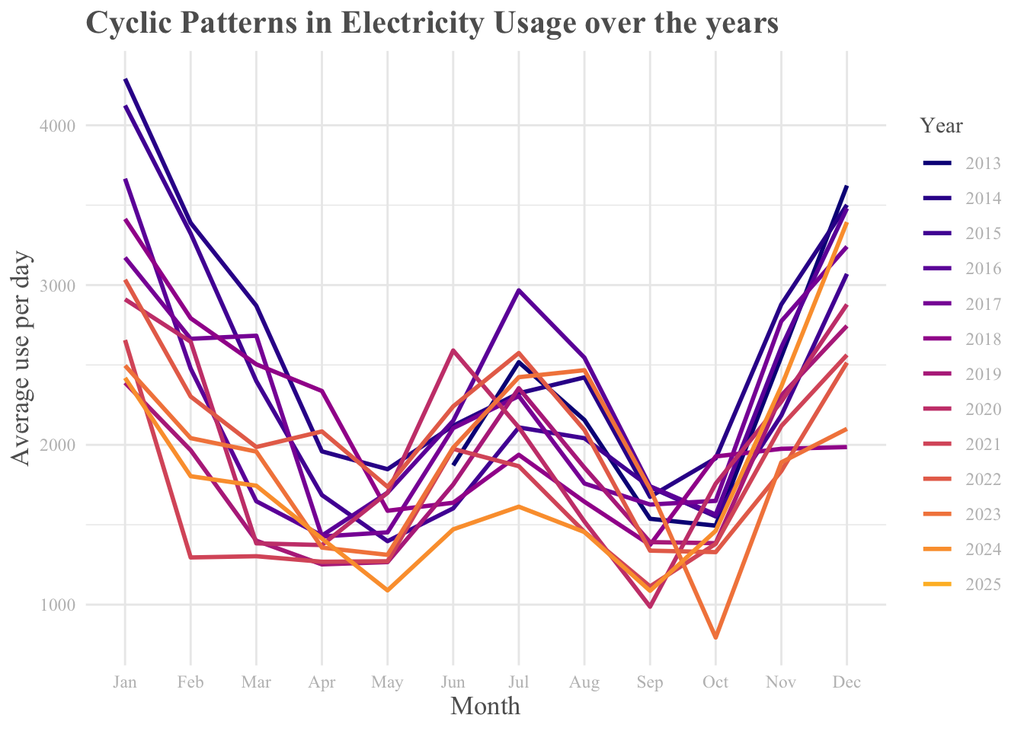

## Methods

When looking at the average energy usage over time at the Old Macalester Presidents House it’s very noticeable that, despite lots of up and down fluctuations, it has a fairly linear relationship with time. Therefore, to model this trend of average energy usage, we use a simple linear regression model to estimate energy usage as a function of time.

$$\text{Average energy usage } = \beta_0 + \beta_1 \cdot \text{Time}$$

Now that we’ve created a model of the trend we can go ahead and remove it from our data to get a de-trended series of use per day. To do this we do the following:
$$\text{Detrended average use per day} = \text{Average use per day } - \text{ Estimated use per day}$$

This looks just like a residual, and in fact it is. These residuals represent how much the actual energy use is above or below the predicted trend at each time point.

Now that we have removed the trend, we go to estimating the seasonality (for the linearly de-trended data) using another regression model to estimate the de-trended series of average use per day as a function of the month.

$$\begin{split}
\text{Detrended average use per day}
& = \beta_0 + \beta_1 *February + \beta_2 *March + \beta_3 *April + \beta_4 *May \\
& + \beta_5 *June + \beta_6 *July + \beta_7 *August + \beta_8 *September \\
& + \beta_9 *October + \beta_10 *November + \beta_11*December
\end{split}$$

In this case, January is treated as the reference month, so the coefficients represent the average difference in energy use for each month relative to January. Once we estimate the seasonality above, we can go ahead and remove it from the de-trended average use per day.

$$\text{Detrended average use per day} = \text{Detrended average use per day } - \text{ Estimate of seasonality}$$

After removing these trends we are left with the residual component, which represents random noise or short-term fluctuations.

These left-over noise ideally captures short term variation in energy usage that is not explained by the trend or recurring monthly patterns. These residuals are often correlated with one another, meaning todays deviation from the expected value might be correlated with those from previous days. To capture this, we model the residuals using an auto regressive order 2 or AR(2) model:
$$Y_t = \phi_1 Y_{t-1} + \phi_2 Y_{t-2} + W_t$$
This means that current residual will depend on the residuals in the previous two time periods. This captures short-term persistence in the energy use fluctuations. For instance, unusually high or low usage tends to continue for a few days before reverting to the mean.

After all this we forecasted the average energy usage for 24 months in the future. We estimated trend and seasonality using the same models as before, and used the AR(2) model to estimate the residuals for each of those months.

$$\begin{split}
\text{Predicted average energy use per day}
& = \beta_0 + \beta_1 \cdot \text{Time} \\
& + \beta_2 *February + \beta_3 *March + \beta_4 *April + \beta_5 *May \\
& + \beta_6 *June + \beta_7 *July + \beta_8 *August + \beta_9 *September \\
& + \beta_10 *October + \beta_11 *November + \beta_12*December \\
& + \phi_1 Y_{t-1} + \phi_2 Y_{t-2} + W_t
\end{split}$$

## Results

We model the linear relationship between average energy usage and time at the Old Macalester President’s House below. Our linear trend shows a constant decrease in electricity use over the years.

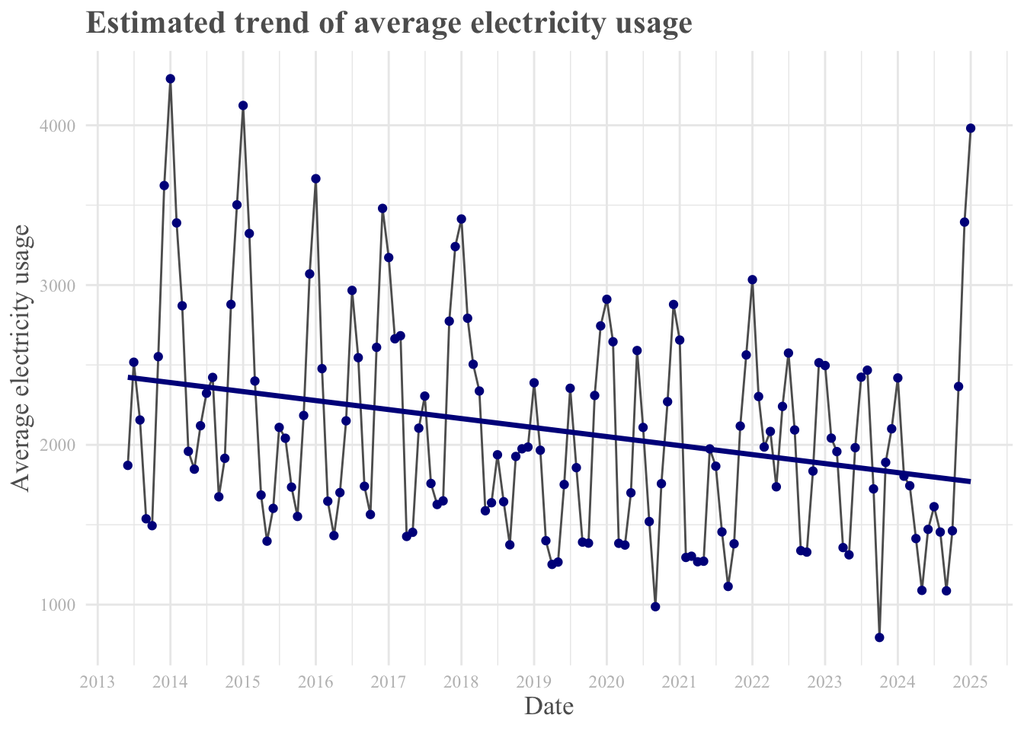

Now if we remove the trend, we no longer see this long negative relationship between energy usage and time, and instead see fluctuations around a constant mean. The fluctuations likely represent seasonality in energy consumption, we will explore this next.

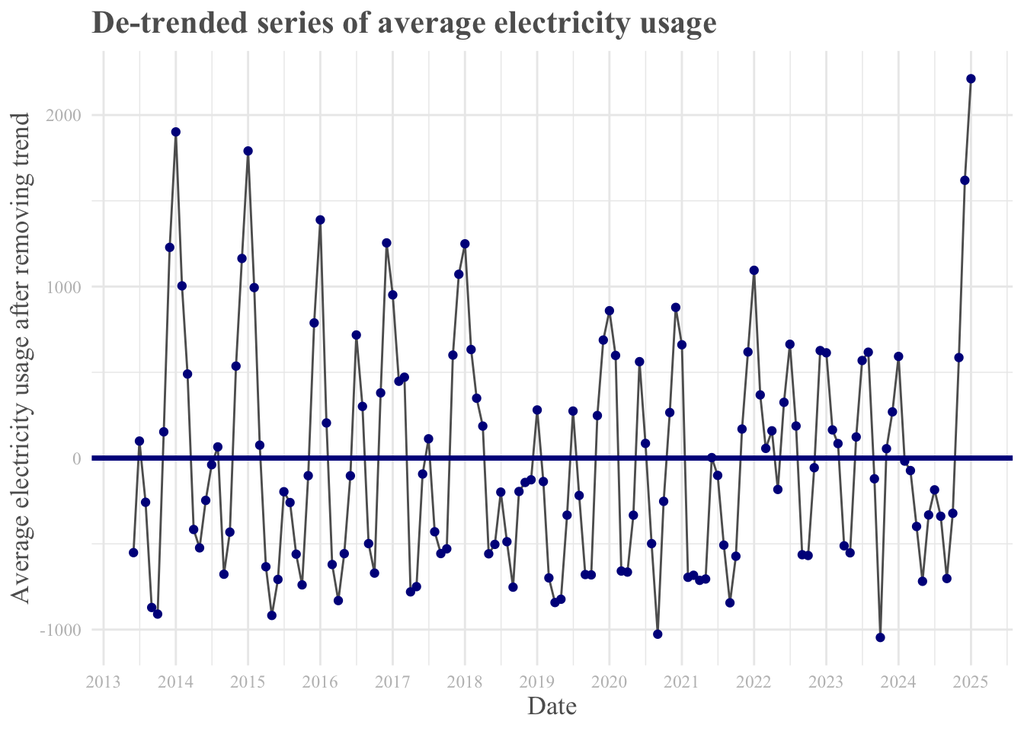

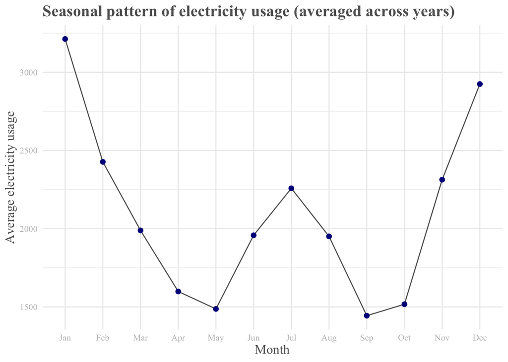

Once we have fully removed the trend and seasonality, we are left with residuals that seem to behave like random noise. This indicates that most of the systematic patterns in energy usage have been accounted for in our trend and seasonality models.

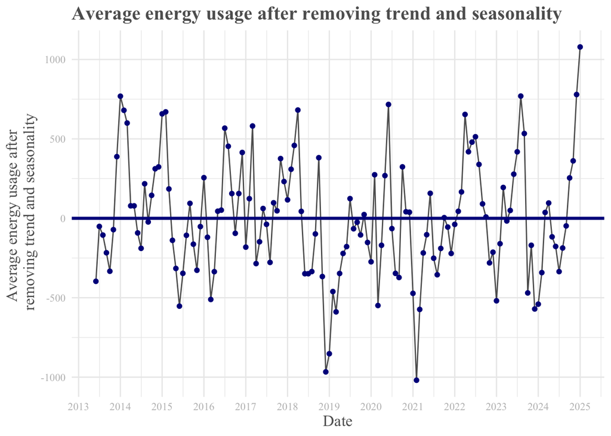

Here we plot the sample autocorrelation function (ACF) and the sample partial autocorrelation function (PACF) of the errors after removing both the trend and seasonality. We see that the ACF decays to zero, and from lag=3 on the correlation remains very close to zero. Then, the PACF seems to drop to zero after about lag=1 or lag=2.

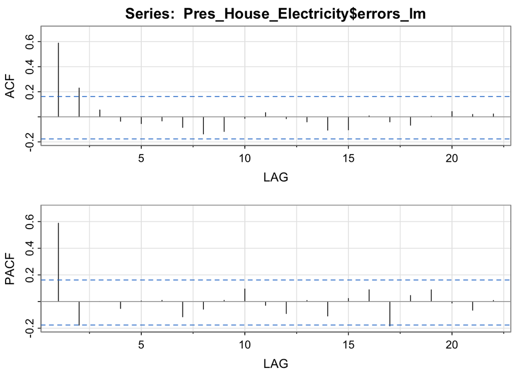

Because of the observations above we have chosen to use either an AR(1) or AR(2) model to model the errors, but we will look further into each one before making our final decision. AR(1) is shown first, then the AR(2).

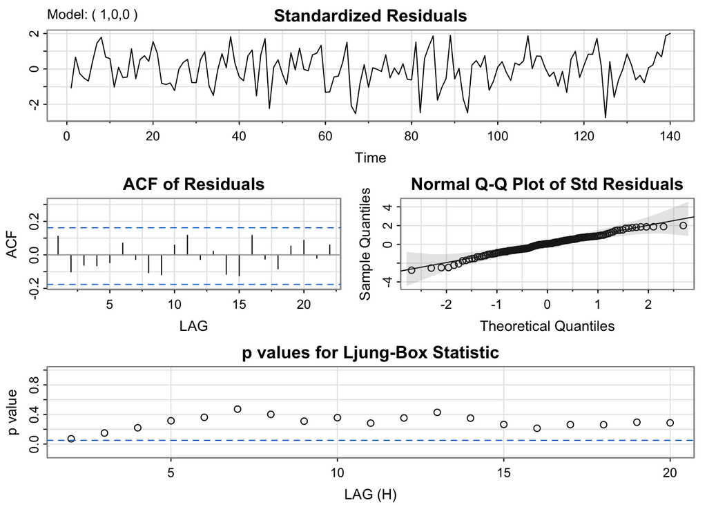

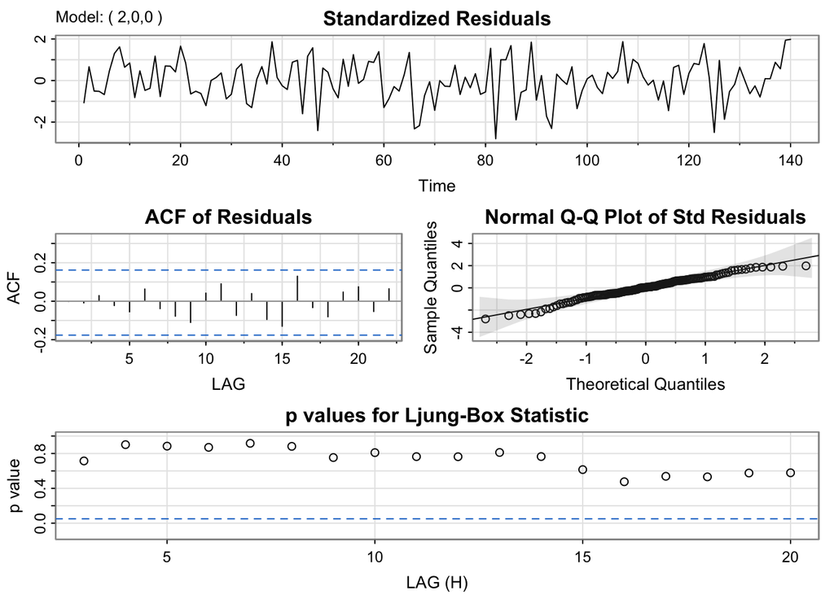

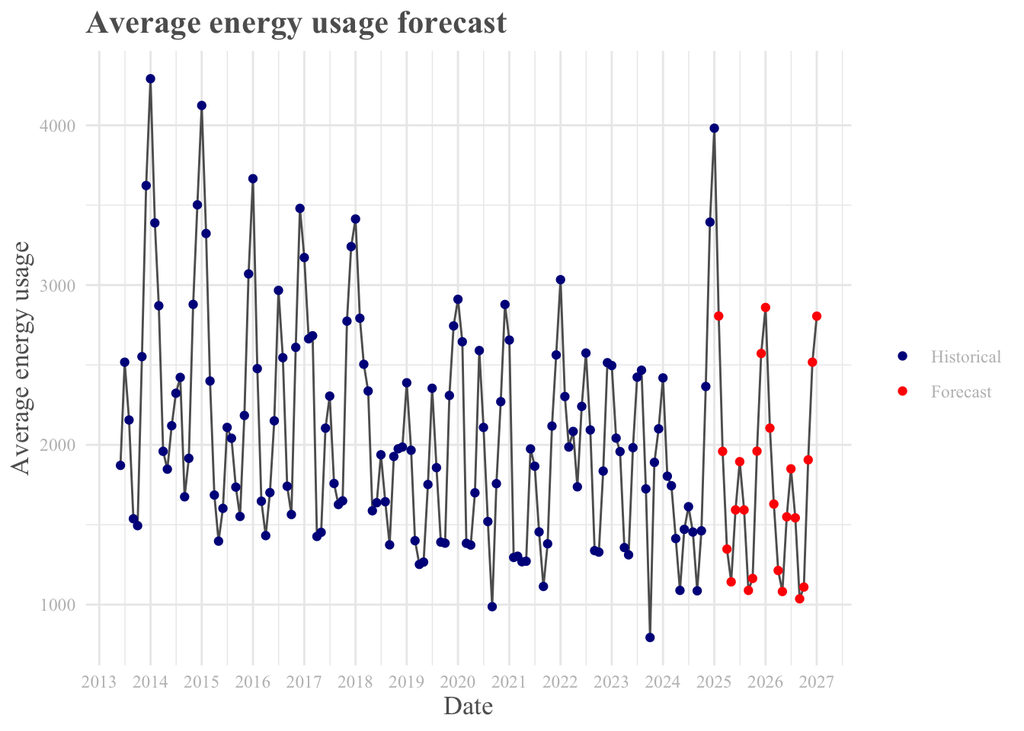

## Conclusions

Our analysis shows us a couple main points: the overall trend of the data is decreasing linearly over time, there is a monthly cyclic trend to the data, and our errors after removing those two components can be modeled with an AR(2) model. One limitation of our work is its singular focus on one building on Macalester’s campus. With more time, ideally we would include many buildings in a more expansive analysis to get a picture of the whole campus electricity use.

Our decreasing linear trend across time tells us that the Old Presidents House is actually making progress in sustainability goals and is using less electricity. Our cyclic patterns tell us that we may want to target the winter months for times to find more efficiency in electricity usage. We could look for ways to reduce heat loss in the house to improve electricity usage further. Our forecasts into the future show these trends continuing into the future. With more intentional use and targeted investment hopefully campus electricity usage can be made more efficient.

## Acknowledgements

Thank you to Quevedo, Geraldi, Melo, Lamberts, and Favela for the background information regarding college campuses and energy consumption. Thank you to Brianna Heggeseth for her Correlated Data Notes which were a key point of reference for specific statistical ideas discussed in the project (Heggeseth (2025)).

## References

Favela, Ruth. 2023. “Moving Toward Sustainability: How College Campuses Are Working to Reduce Energy Consumption.”

Heggeseth, Brianna. 2025. “Correlated Data Notes.”

Quevedo, T. C., M. S. Geraldi, A. P. Melo, and R. Lamberts. 2024. “Benchmarking Energy Consumption in Universities: A Review.” *Journal of Building Engineering* 82: 108185. https://doi.org/https://doi.org/10.1016/j.jobe.2023.108185.